# Introdução à Análise de Ações com R

[figure not shown]

# Introdução à Análise de Ações com R

A análise de ações e investimentos é um tema que pode ser muito bem explorado na programação.

Isso inclui a linguagem R, que já possui vasta literatura, pacotes e funções desenvolvidas no tema.

Nesta aula faremos uma breve introdução ao assunto utilizando os pacotes `quantmod` e `ggplot2`.

## Como será nossa análise

Além disso, o pacote [ggplot2](https://cran.r-project.org/web/packages/ggplot2/index.html) será utilizado para a visualização dos dados.

## Preparando o ambiente

Primeiramente, instalamos e carregamos os pacotes necessários.

```r
rm(list=ls())
install.packages("quantmod")
install.packages('Rcpp', dependencies = TRUE)
install.packages('ggplot2', dependencies = TRUE)
install.packages("vctrs", dependencies = TRUE)
```

Agora vamos carregar os pacotes instalados

```r
library(quantmod)
library(ggplot2)
```

Depois de termos os pacotes instalados e carregados, vamos baixar a série de preços da ação e tratar os dados para que fiquem da melhor forma possível para a realização das análises. Isso é feito por meio do comando `getSymbols`.

```r
pbr <- getSymbols("PBR", src = "yahoo", from = "2013-01-01", to = "2020-06-01", auto.assign = FALSE)
```

O primeiro argumento `PBR` é o símbolo do ativo que queremos analisar no Yahoo Finance. Você pode procurar pelo símbolo de outra ação ou índice que desejar analisar clicando [aqui](https://finance.yahoo.com/lookup/).

O argumento `src = "yahoo"` indica a fonte dos dados. Também podemos utilizar outras fontes como o Google Finance, FRED, Oanda, bancos de dados locais, CSVs e vários outros.

O terceiro e quarto argumentos indicam o período no qual os dados serão extraídos, com a data no formato “aaaa-mm-dd”.

Por último, o argumento `auto.assign = FALSE` nos permite nomear o dataset com o nome que quisermos. Caso seja TRUE, o nome será automaticamente o símbolo que estamos buscando, ou seja, o primeiro argumento.

## Adendo

Caso a API do Yahoo Finance não esteja funcionando, é possível baixar a base de preços diretamente do site.

Basta buscar pelo tick da ação ou pelo nome da empresa. Na página do ativo, basta clicar em “Historical Data”, conforme imagem abaixo:

[figure not shown]

Depois, basta selecionar o período desejado e clicar em “Download Data”. O arquivo baixado estará no formato csv.

Agora é só colocá-lo no seu working directory, que pode ser descoberto utilizando o comando `getwd()`.

`pbr <- read.csv("PBR.csv")`  
`pbr[,1] <- as.Date(pbr[,1])`  
`pbr <- xts(pbr)`  
`pbr <- pbr[,-1]`

# Visualização de Preços

Agora vamos dar uma breve olhada nos dados, apenas para conhecê-los melhor. Rode as linhas a seguir e analise cada output.

```r
head(pbr)
```

[output not shown]

```r
tail(pbr)
```

[output not shown]

```r
summary(pbr)
```

[output not shown]

```r
str(pbr)
```

[output not shown]

Pelos comandos `head()` e `tail()` podemos ver as primeiras e últimas 6 linhas da base.

São 6 colunas com: preço de abertura, preços máximo e mínimo do dia, preço de fechamento, volume de transações e preço ajustado.

Pelo comando `summary` verificamos as estatísticas descritivas de cada série de preços e volume.

Já o comando `str` fornece a estrutura do objeto. Neste caso, é um objeto [xts](https://cran.r-project.org/web/packages/xts/vignettes/xts.pdf), uma série temporal.

Vamos agora plotar os preços diários, utilizando a coluna de Preço Ajustado, visto que ela incorpora eventos como splits e distribuição de dividendos, que podem afetar a série.

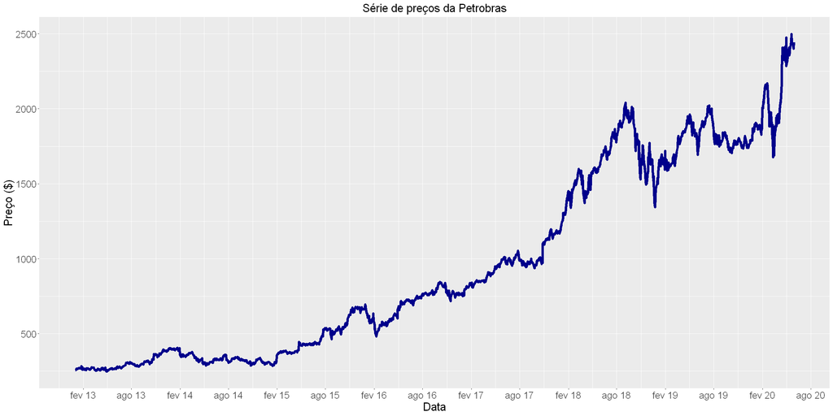

```r
library(repr)
options(repr.plot.width = 20, repr.plot.height = 10)
ggplot(pbr, aes(x = index(pbr), y = pbr[,6])) + geom_line(color = "darkblue", size=2) +
ggtitle("Série de preços da Petrobras") +
xlab("Data") + ylab("Preço ($)") +
theme(plot.title = element_text(hjust = 0.5, size=20)) +
theme(text = element_text(size = 20))+
scale_x_date(date_labels = "%b %y", date_breaks = "6 months")
```

Criamos esse gráfico usando o comando ggplot.

Antes de tudo carregamos o pacote repr e com o comando options(repr.plot.width = 20, repr.plot.height = 10) ajustamos o tamanho do gráfcio para 20 x 10

Primeiro utilizamos o objeto pbr como a série a ser plotada.

Depois indicamos quais elementos serão os eixos: index(pbr), a data no eixo x, e a coluna de preço ajustado, pbr[,6], no eixo y.

Em seguida, adicionamos o elemento a ser plotado, no caso, uma linha azul: geom_line(color = "darkblue").

Depois, acrescentamos o título e nomes dos eixos, com os comandos ggtitle("Série de preços da Petrobras"), xlab("Data"), ylab("Preço ($)").

Por padrão, o título do gráfico fica alinhado à esquerda. Para centralizá-lo, utilizamos theme(plot.title = element_text(hjust = 0.5)).

Usamos theme(text = element_text(size = 20)) para ajustar o tamaho da fonte para 20

Por último, para deixar o eixo temporal com mais informações, colocamos o tick de data a cada seis meses e na forma de mmm aa utilizando scale_x_date(date_labels = "%b %y", date_breaks = "6 months").

Em [Análise Técnica](https://pt.wikipedia.org/wiki/An%C3%A1lise_t%C3%A9cnica) de ações, uma técnica muito utilizada é a plotagem de médias móveis nos gráficos de preços. Uma média móvel simples é a média aritmética dos últimos $q$ dias de uma série $x_t$ no período de tempo $t$. Assim, a média móvel $MM_{qt}$ é dada por: $$ MM_{t}^{q}= \frac{1}{q}\sum_{i=0}^{q-1}x_{t-1} $$

Esse indicador é interessante pois ajuda a identificar tendências e suaviza ruídos dos preços.

Isto é, quanto maior a janela de dias para o cálculo da média, menor é a responsividade da MM à variação no preço.

Quanto menor a janela, mais rápido à média móvel se ajusta às mudanças.

Vamos então calcular agora duas médias móveis para a série de preços da Petrobras, uma com janela de 10 dias e outra com janela de 30 dias:

```r
pbr_mm <- subset(pbr, index(pbr) >= "2016-01-01")

pbr_mm10 <- rollmean(pbr_mm[,6], 10, fill = list(NA, NULL, NA), align = "right")
pbr_mm30 <- rollmean(pbr_mm[,6], 30, fill = list(NA, NULL, NA), align = "right")

pbr_mm$mm10 <- coredata(pbr_mm10)
pbr_mm$mm30 <- coredata(pbr_mm30)
```

Primeiro dividimos a base para dados a partir de 2016 utilizando a função subset().

Em seguida, usamos a função rollmean(), que toma como argumento a série $x_t$ , no caso o preço ajustado; a janela de períodos ($q$); um argumento opcional de preenchimento, que é utilizado para completar os dias em que ainda não é possível calcular a média móvel, ou seja, quando não se passaram dias suficiente para completar a janela desejada; e, por último, o argumento align, que indica se a média móvel deve ser calculada usando os períodos à esquerda, ao centro ou à direita do dia $t$ da série.

Por último, acrescentamos as médias móveis a duas novas colunas na base inicial.

Em nosso caso, calculamos utilizando 10 e 30 dias de janela, preenchendo os valores com NA e utilizando os períodos à esquerda do dia em questão.

Em seguida, podemos plotar ambas as séries no mesmo gráfico de preços para identificar tendências. Uma teoria existente na Análise Técnica é a de que quando duas médias móveis de janelas de curto e longo prazo se cruzam, há uma indicação de compra ou de venda.

Caso a MM de menor período cruze de baixo para cima a MM de maior período, há uma indicação de compra. Se o cruzamento for o contrário, é um sinal de **venda**.

Plotando a série de preços e as médias móveis para todos os dias a partir de 2016, temos:

```
Warning message:
"Removed 9 row(s) containing missing values (geom_path)."
Warning message:
"Removed 29 row(s) containing missing values (geom_path)."
```

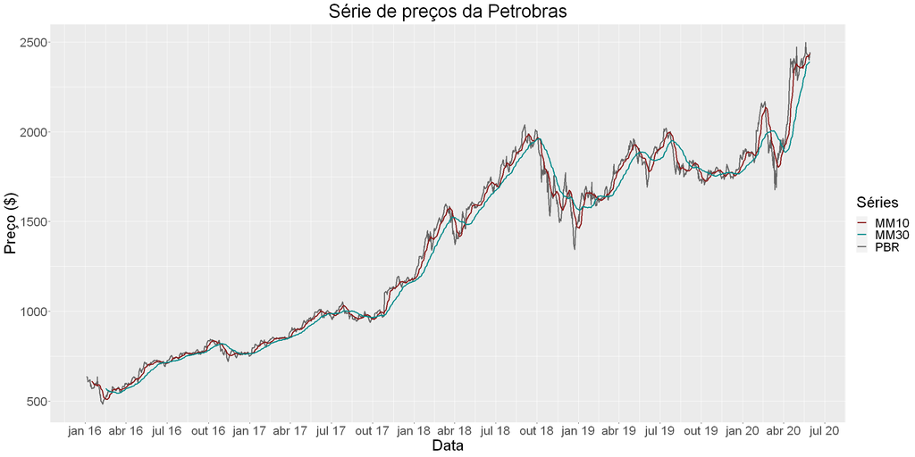

```r
ggplot(pbr_mm, aes(x = index(pbr_mm))) + geom_line(aes(y = pbr_mm[,6], color = "PBR"), size=1) +
ggtitle("Série de preços da Petrobras") +
geom_line(aes(y = pbr_mm$mm10, color = "MM10"), size=1) +
geom_line(aes(y = pbr_mm$mm30, color = "MM30"), size=1) +
xlab("Data") + ylab("Preço ($)") +
theme(plot.title = element_text(hjust = 0.5), panel.border = element_blank()) +
theme(text = element_text(size = 24))+
scale_x_date(date_labels = "%b %y", date_breaks = "3 months") +
scale_colour_manual("Séries", values=c("PBR"="gray40", "MM10"="firebrick4", "MM30"="darkcyan"))
```

Para criar o gráfico, plotamos a linha de preços e as linhas das médias móveis.

Nesta ocasião, utilizamos de forma diferente a plotagem de cada linha, criando uma espécie de apelido para as cores de cada uma.

Em seguida, adicionamos a linha scale_colour_manual, indicando a cor de cada apelido para que as cores constassem na legenda de cada série.

## Retornos!

Vimos como o preço da ação tem variado ao longo do tempo. Vamos agora verificar como se comportou o retorno da ação no mesmo período.

Para isso, precisamos primeiro criar um novo objeto com os retornos calculados, utilizando também a coluna de preço ajustado:

```r
pbr_ret <- diff(log(pbr[,6]))
pbr_ret <- pbr_ret[-1,]
```

O que fizemos aqui foi utilizar as propriedades do logaritmo para calcular o retorno logarítmico da ação. Ou seja, fizemos: $$ r_{t}= ln(1+R_{t})= ln(\frac{P_{t}}{P_{t-1}})= ln(P_{t})-ln(P_{t-1})\approx R_{t} $$

O comando diff calcula a diferença de todos os valores de algum vetor ou elemento. Com isso, apenas aplicamos a diferença aos logaritmos naturais dos preços da ação.

Além desse modo, é possível calcular os retornos de forma diferente. O pacote quantmod possui algumas funções interessantes para isso.

Primeiramente, é bastante fácil selecionar apenas uma coluna de preços de cada ação, por exemplo:

```r
head(Op(pbr))
```

```
           AMZN.Open
2013-01-02    256.08
2013-01-03    257.27
2013-01-04    257.58
2013-01-07    262.97
2013-01-08    267.07
2013-01-09    268.17
```

```r
head(Cl(pbr))
```

```
           AMZN.Close
2013-01-02     257.31
2013-01-03     258.48
2013-01-04     259.15
2013-01-07     268.46
2013-01-08     266.38
2013-01-09     266.35
```

```r
head(Ad(pbr))
```

```
           AMZN.Adjusted
2013-01-02        257.31
2013-01-03        258.48
2013-01-04        259.15
2013-01-07        268.46
2013-01-08        266.38
2013-01-09        266.35
```

Todos esses comandos tornam a análise e os cálculos muito mais rápidos e fáceis de serem feitos.

```r
summary(pbr_ret)
```

```
     Index            AMZN.Adjusted
 Min.   :2013-01-03   Min.   :-0.116503
 1st Qu.:2014-11-06   1st Qu.:-0.007426
 Median :2016-09-14   Median : 0.001196
 Mean   :2016-09-14   Mean   : 0.001207
 3rd Qu.:2018-07-23   3rd Qu.: 0.010734
 Max.   :2020-05-29   Max.   : 0.132178
```

```r
sd(pbr_ret)
```

0.0190142323742705

```r
mean(pbr_ret)
```

0.00120731900769929

Podemos agora plotar um gráfico dos retornos e ver como eles desempenharam ao longo do tempo:

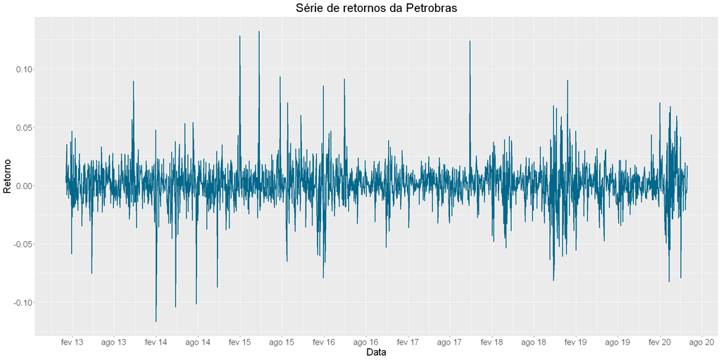

```r
ggplot(pbr_ret, aes(x = index(pbr_ret), y = pbr_ret)) + geom_line(color = "deepskyblue4",  size=1) +
ggtitle("Série de retornos da Petrobras") + xlab("Data") + ylab("Retorno") +
theme(plot.title = element_text(hjust = 0.5)) +
theme(text = element_text(size = 20))+
scale_x_date(date_labels = "%b %y", date_breaks = "6 months")
```

Vamos fazer agora uma breve checagem dos retornos da ação em 2020:

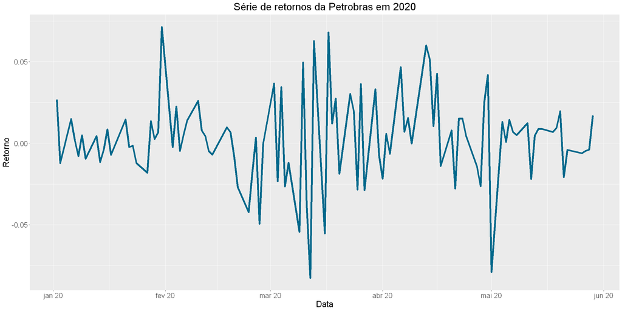

```r
pbr_ret20 <- subset(pbr_ret, index(pbr_ret) > "2020-01-01")

ggplot(pbr_ret20, aes(x = index(pbr_ret20), y = pbr_ret20)) + geom_line(color = "deepskyblue4",  size=2) +
ggtitle("Série de retornos da Petrobras em 2020") + xlab("Data") + ylab("Retorno") +
theme(plot.title = element_text(hjust = 0.5)) +
theme(text = element_text(size = 20))+
scale_x_date(date_labels = "%b %y", date_breaks = "1 months")
```

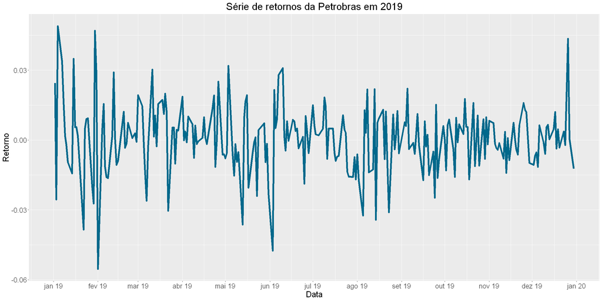

```r
pbr_ret19 <- subset(pbr_ret, (index(pbr_ret) > "2019-01-01")&(index(pbr_ret) < "2019-12-31"))

ggplot(pbr_ret19, aes(x = index(pbr_ret19), y = pbr_ret19)) +
geom_line(color = "deepskyblue4", size=2) +
ggtitle("Série de retornos da Petrobras em 2019") + xlab("Data") + ylab("Retorno") +
theme(plot.title = element_text(hjust = 0.5)) +
theme(text = element_text(size = 20))+
scale_x_date(date_labels = "%b %y", date_breaks = "1 months")
```

```r
summary(pbr_ret20)

mean(pbr_ret20)

sd(pbr_ret20)
```

```
     Index            AMZN.Adjusted
 Min.   :2020-01-02   Min.   :-0.082535
 1st Qu.:2020-02-08   1st Qu.:-0.010540
 Median :2020-03-17   Median : 0.004478
 Mean   :2020-03-16   Mean   : 0.002708
 3rd Qu.:2020-04-22   3rd Qu.: 0.014650
 Max.   :2020-05-29   Max.   : 0.071196
```

0.00270826753672114

0.0270156005554484

```r
summary(pbr_ret19)

mean(pbr_ret19)

sd(pbr_ret19)
```

```
     Index            AMZN.Adjusted
 Min.   :2019-01-02   Min.   :-0.0553212
 1st Qu.:2019-04-02   1st Qu.:-0.0066713
 Median :2019-07-02   Median : 0.0012141
 Mean   :2019-07-01   Mean   : 0.0008236
 3rd Qu.:2019-09-30   3rd Qu.: 0.0087527
 Max.   :2019-12-30   Max.   : 0.0488511
```

0.00082360793252136

0.0144595060589382